# R Notebook

Channel Head Temp Report 7_18_19

The stream temperature sensors were all collected the other day after being deployed for 25 days, and I’ve been playing around with the data. The sensors collected the temp every 10 minutes. 2 sensors were deployed at the channel head and ~200 m downstream. Additionally, an air temp was recorded at the head of one of the channels in each watershed.

Data time period Start date: 6-13-19 13:10 End date: 7-8-19 11:20

Things I want to show: -maps of sheds for reference -General temp time series -Distribution of temps (ridge plots) -Diff between heads and downstream -temps normalized by air temp

```r
#Load packages
library(tidyverse)
library(ggridges)
library(lubridate)
library(SAVER)
```

```r
master.tall$rnd.dates <- master.tall$rnd.dats %>% as.POSIXct(format = "%Y-%M-%d %H:%M:%S")
```

```
Error in as.POSIXct.default(., format = "%Y-%M-%d %H:%M:%S") :
  do not know how to convert '.' to class “POSIXct”
```

Basic temperature trends/timeseries

First plot is the temps from each site in Moses Creek (RMO) for the entire deployment. The second plot is the same thing with the AirT removed.

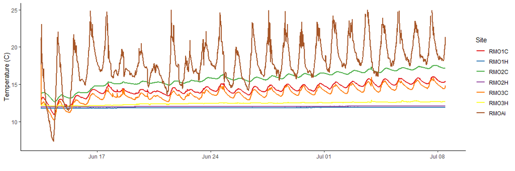

```r
#filtering out duplicate sites/sensors- just for this plotting
all.ts <- c("ULB2HA","ULB3HA", "ULB4HA", "RMO1HA", "RMO2HA", "RMO3HB", "MUL2HA",  "MUL4HB",  "MUL7HB", "W600B", "GC300B", "LS180B","ULB2CB", "ULB3CB", "ULB4CA", "RMO1CB",  "RMO2CB",  "RMO3CB", "MUL2CB", "MUL4CA",  "MUL7CA", "W400A", "GC100B",  "LS0B", "MULAir", "GGAir", "RMOAir", "ULBAir")

one.sens <- master.tall %>% filter(site %in% all.ts)
one.sens$site <- gsub('.{1}$', '', one.sens$site)
timeseries <- one.sens
#rmo with airT
rmo.ts <- timeseries %>% filter(shed == "RMO")
rmo.ts.plot <- ggplot(data = rmo.ts,
                      aes(x = rnd.dates,
                          y = Value,
                          color = site))+
  geom_line(size = 1)+
  scale_color_brewer(palette = "Set1",
                     name = "Site")+
  xlab(" ")+
  ylab("Temperature (C)")+
  ylim(7,25)+
  theme_classic()
rmo.ts.plot
```

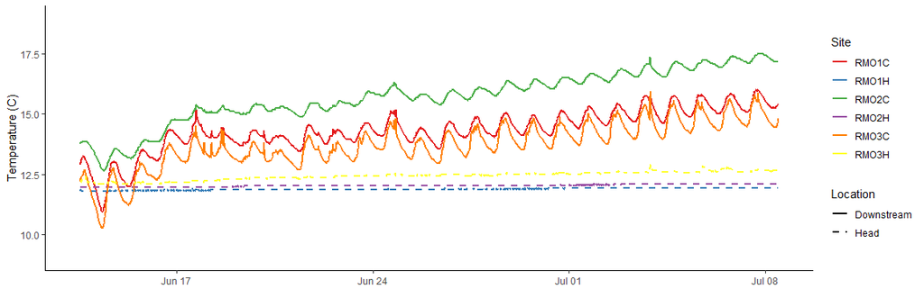

```r
#rmo without airT
rmo.ts2 <- timeseries %>% filter(shed == "RMO" & type != "air")
rmo.ts.plot2 <- ggplot(data = rmo.ts2,
                       aes(x = rnd.dates,
                           y = Value,
                           color = site,
                           linetype = type))+
  geom_line(size = 1)+
  scale_color_brewer(palette = "Set1",
                     name = "Site")+
  scale_linetype_manual(labels = c("Downstream", "Head"),
                        values=c("solid", "dashed"),
                        name = "Location")+
  xlab(" ")+
  ylab("Temperature (C)")+
  ylim(9,19)+
  theme_classic()
rmo.ts.plot2
```

Plots of Mull Creek timeseries- first with AirT, second without AirT

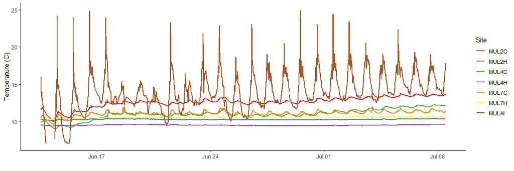

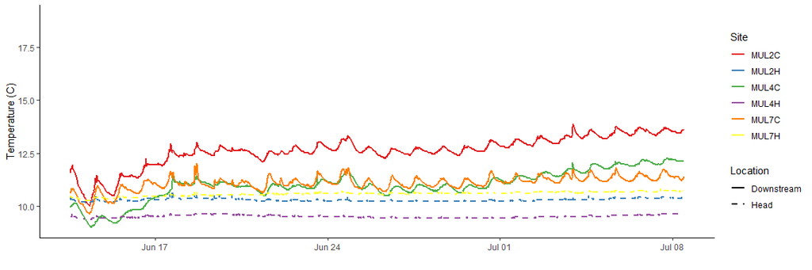

Plots of Long Branch timeseries- first with AirT, second without AirT

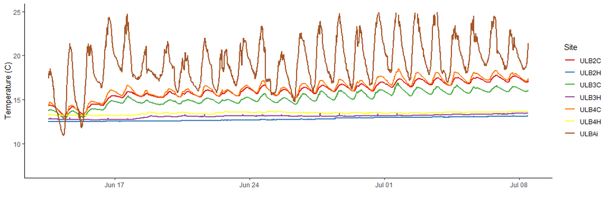

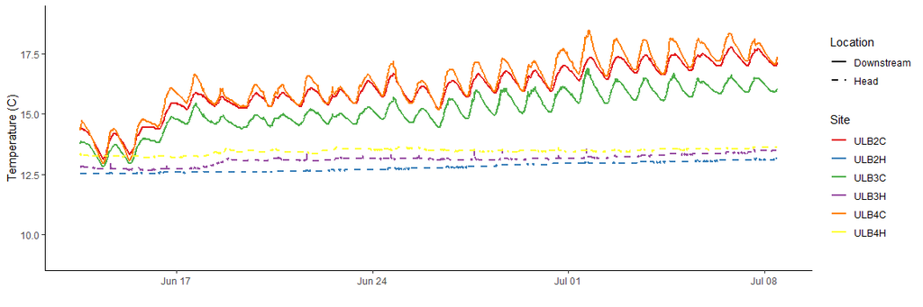

Plots of Gribble Gap timeseries- first with AirT, second without AirT

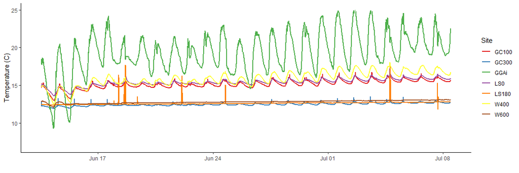

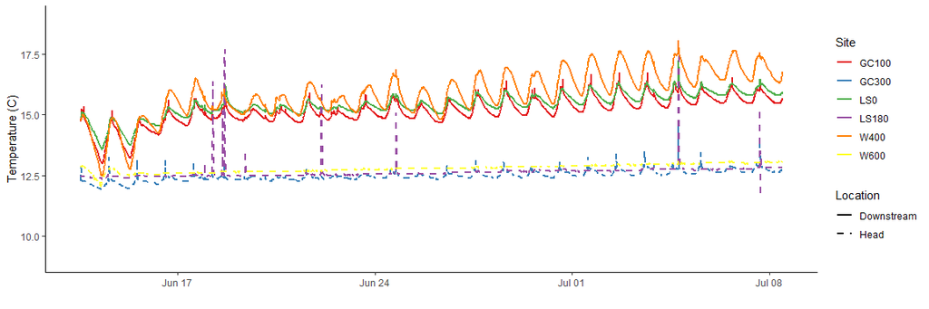